# Labour force analysis by industry

# Agriculture, Forestry and Fishing

*Last updated on 2020-09-18.*

A total of 324,499 individuals were employed in Agriculture, Forestry and Fishing in Feb 2020, before the onset of COVID-19 spread in Australia.

A total of 354,545 individuals were employed in the most recent quarter of May 2020, which is an increase of 9.26 percentage points since Feb 2020.

## Change in employment growth/decline

We can visualise the change in employment for Agriculture, Forestry and Fishing compared to all other industries as the rate of employment growth or decline since Nov 1984.

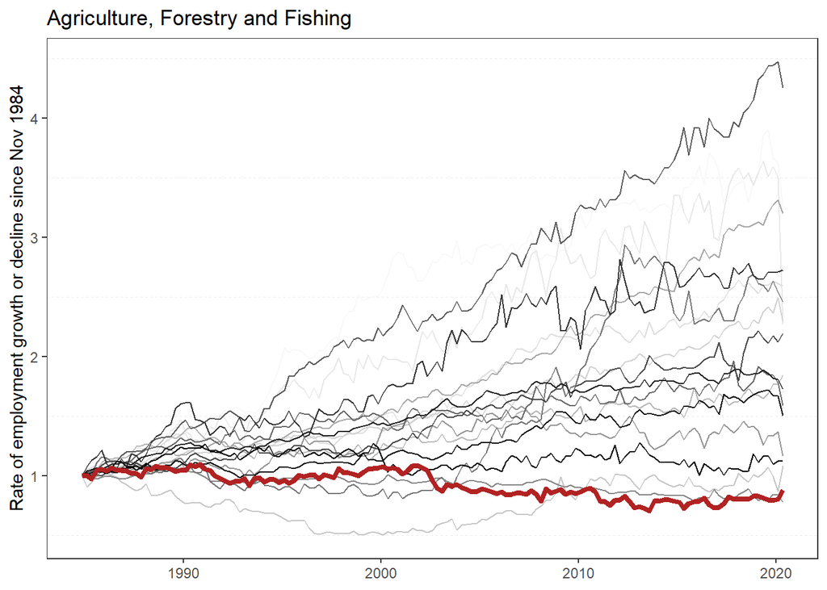

## Number of employed persons over time

We can visualise the total number of employed persons for Agriculture, Forestry and Fishing since Nov 1984.

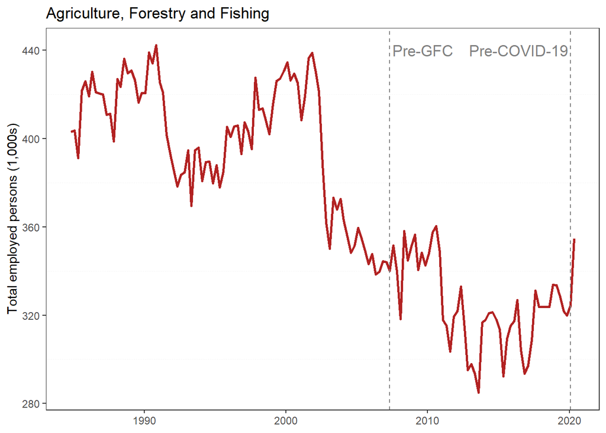

## Changes in total persons employed over time

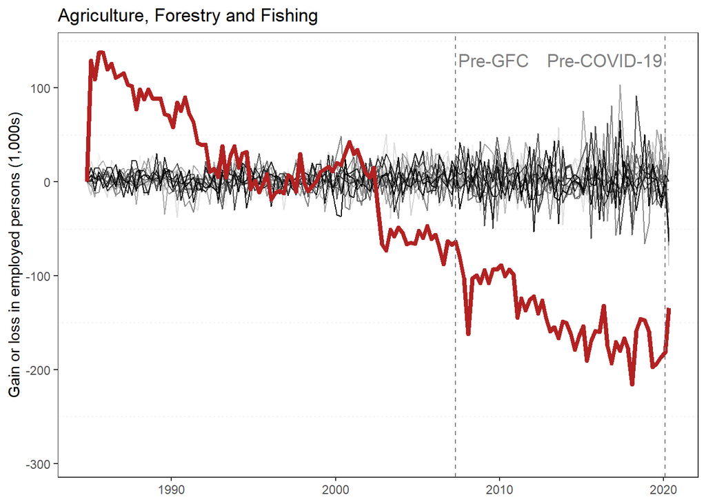

**Note**: The trend for Agriculture, Forestry and Fishing is highlighted in red.